# Movies Recommendation System Using Content Filtering

Akash Lamba

### Overview

- https://movielens.org is a movie recommendations website run by the GroupLens Research Lab at the University of Minnesota.
- They collect user preferences about movies and do collaborative filtering to make recommendations.
- We will use their movie database to do content filtering using clustering technique.

[figure not shown]

### MovieLens Items Dataset

- Movies in the dataset are categorized as belonging to different generes.

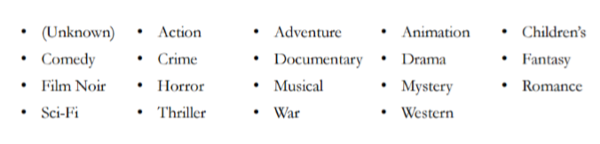

- Each movie may belong to many genres.
- We will systematically group movies with similar set of genres using different clustering techniques.

### Importing the data

```r
movies<-read.csv("http://files.grouplens.org/datasets/movielens/ml-100k/u.item", header = FALSE, sep = "|")
```

### Structure

- We have 1682 Observations of 24 different variables.

```r
str(movies)
```

```
## 'data.frame':    1682 obs. of  24 variables:
##  $ V1 : int  1 2 3 4 5 6 7 8 9 10 ...
##  $ V2 : Factor w/ 1664 levels "'Til There Was You (1997)",..: 1525 618 555 594 344 1318 1545 111 391 1240 ...
##  $ V3 : Factor w/ 241 levels "","01-Aug-1997",..: 71 71 71 71 71 71 71 71 71 182 ...
##  $ V4 : logi  NA NA NA NA NA NA ...
##  $ V5 : Factor w/ 1661 levels "","http://us.imdb.com/M/title-exact/Independence%20(1997)",..: 1431 565 505 543 310 1661 1453 103 357 1183 ...
##  $ V6 : int  0 0 0 0 0 0 0 0 0 0 ...
##  $ V7 : int  0 1 0 1 0 0 0 0 0 0 ...
##  $ V8 : int  0 1 0 0 0 0 0 0 0 0 ...
##  $ V9 : int  1 0 0 0 0 0 0 0 0 0 ...
##  $ V10: int  1 0 0 0 0 0 0 1 0 0 ...
##  $ V11: int  1 0 0 1 0 0 0 1 0 0 ...
##  $ V12: int  0 0 0 0 1 0 0 0 0 0 ...
##  $ V13: int  0 0 0 0 0 0 0 0 0 0 ...
##  $ V14: int  0 0 0 1 1 1 1 1 1 1 ...
##  $ V15: int  0 0 0 0 0 0 0 0 0 0 ...
##  $ V16: int  0 0 0 0 0 0 0 0 0 0 ...
##  $ V17: int  0 0 0 0 0 0 0 0 0 0 ...
##  $ V18: int  0 0 0 0 0 0 0 0 0 0 ...
##  $ V19: int  0 0 0 0 0 0 0 0 0 0 ...
##  $ V20: int  0 0 0 0 0 0 0 0 0 0 ...
##  $ V21: int  0 0 0 0 0 0 1 0 0 0 ...
##  $ V22: int  0 1 1 0 1 0 0 0 0 0 ...
##  $ V23: int  0 0 0 0 0 0 0 0 0 1 ...
##  $ V24: int  0 0 0 0 0 0 0 0 0 0 ...
```

### Preprocessing

- Since there are no names of the columns, So we will give them.

```r
colnames(movies)=c("ID", "Title", "ReleaseDate", "VideoReleaseDate", "IMDB", "Unknown", "Action", "Adventure", "Animation", "Children", "Comedy", "Crime", "Documentary", "Drama", "Fantasy", "FilmNoir", "Horror", "Musical", "Mystery", "Romance", "SciFi", "Thriller", "War", "Western")
```

- We won’t be using the ID,release date,video release date,or IMDB variables.

```r
movies$ID = NULL
movies$ReleaseDate = NULL
movies$VideoReleaseDate = NULL
movies$IMDB = NULL
```

- We will also remove the duplicate entries in our dataset.

```r
movies <- unique(movies)
str(movies)
```

```
## 'data.frame':    1664 obs. of  20 variables:
##  $ Title      : Factor w/ 1664 levels "'Til There Was You (1997)",..: 1525 618 555 594 344 1318 1545 111 391 1240 ...
##  $ Unknown    : int  0 0 0 0 0 0 0 0 0 0 ...
##  $ Action     : int  0 1 0 1 0 0 0 0 0 0 ...
##  $ Adventure  : int  0 1 0 0 0 0 0 0 0 0 ...
##  $ Animation  : int  1 0 0 0 0 0 0 0 0 0 ...
##  $ Children   : int  1 0 0 0 0 0 0 1 0 0 ...
##  $ Comedy     : int  1 0 0 1 0 0 0 1 0 0 ...
##  $ Crime      : int  0 0 0 0 1 0 0 0 0 0 ...
##  $ Documentary: int  0 0 0 0 0 0 0 0 0 0 ...
##  $ Drama      : int  0 0 0 1 1 1 1 1 1 1 ...
##  $ Fantasy    : int  0 0 0 0 0 0 0 0 0 0 ...
##  $ FilmNoir   : int  0 0 0 0 0 0 0 0 0 0 ...
##  $ Horror     : int  0 0 0 0 0 0 0 0 0 0 ...
##  $ Musical    : int  0 0 0 0 0 0 0 0 0 0 ...
##  $ Mystery    : int  0 0 0 0 0 0 0 0 0 0 ...
##  $ Romance    : int  0 0 0 0 0 0 0 0 0 0 ...
##  $ SciFi      : int  0 0 0 0 0 0 1 0 0 0 ...
##  $ Thriller   : int  0 1 1 0 1 0 0 0 0 0 ...
##  $ War        : int  0 0 0 0 0 0 0 0 0 1 ...
##  $ Western    : int  0 0 0 0 0 0 0 0 0 0 ...
```

### Hierarchical Clustering

- We will use Hierarchical Clustering to cluster the movies in the movielens dataset by genre.
- After we make clusters we will see how they can be used to make recommendations.
- There are 2 steps to hierarchical clustering :
  - First we need to compute the distances between points
  - Second, we need to Cluster the points

#### Distance

- We only want to cluster our movies on genre variable, not on the title variable, so we will calculate the distance on columns two through 20.

```r
Distance <- dist(movies[2:20],method="euclidean")
```

#### Clustering

- We will cluster our movies using the `hclust()` for hierarchichal Clustering.
- We will call the output `clusterMovies`.
- We will use the `ward.D` method. The ward method cares about the distance between clusteres using centroid distance, and also the variance in each of the clusters.

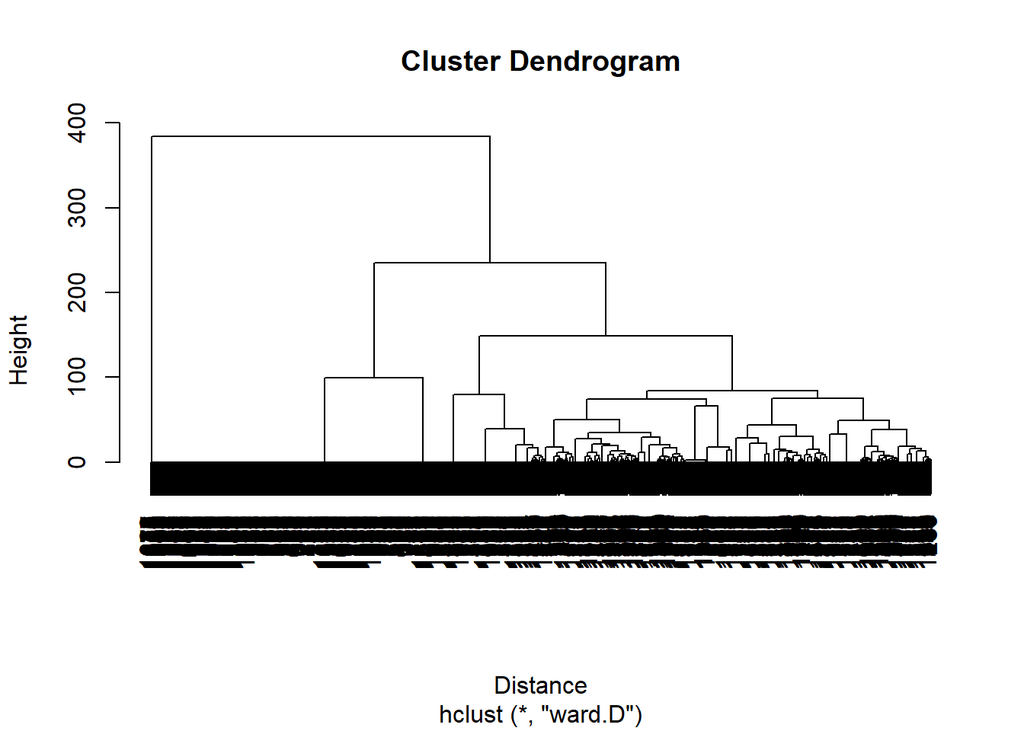

```r
clusterMovies <- hclust(d=Distance,method ="ward.D")
plot(clusterMovies)
```

*We will use 10 clusters for now from the dendogram*

#### Labelling of the Data Points

- We need to label each of Data Points according to what cluster it belongs.
- This can be done using the `cutree()`.

```r
clusterGroups <- cutree(clusterMovies,k=10)
```

- We will use the `tapply()` to compute the percentage of movies in each genre and cluster.

```r
tapply(movies$Action, clusterGroups, mean)
```

```
##         1         2         3         4         5         6         7
## 0.1784512 0.7839196 0.1238532 0.0000000 0.0000000 0.1015625 0.0000000
##         8         9        10
## 0.0000000 0.0000000 0.0000000
```

- We wil use the `aggregate()` to compute the percentage of All the movies in each genre and cluster.

```r
agg <- aggregate(movies[2:20],list(clusterGroups),mean)
agg
```

```
##    Group.1     Unknown    Action  Adventure  Animation    Children
## 1        1 0.006734007 0.1784512 0.18518519 0.13468013 0.393939394
## 2        2 0.000000000 0.7839196 0.35175879 0.01005025 0.005025126
## 3        3 0.000000000 0.1238532 0.03669725 0.00000000 0.009174312
## 4        4 0.000000000 0.0000000 0.00000000 0.00000000 0.000000000
## 5        5 0.000000000 0.0000000 0.00000000 0.00000000 0.000000000
## 6        6 0.000000000 0.1015625 0.00000000 0.00000000 0.000000000
## 7        7 0.000000000 0.0000000 0.00000000 0.00000000 0.000000000
## 8        8 0.000000000 0.0000000 0.00000000 0.00000000 0.000000000
## 9        9 0.000000000 0.0000000 0.00000000 0.00000000 0.000000000
## 10      10 0.000000000 0.0000000 0.00000000 0.00000000 0.000000000
##        Comedy       Crime Documentary     Drama     Fantasy  FilmNoir
## 1  0.36363636 0.033670034  0.01010101 0.3063973 0.070707071 0.0000000
## 2  0.06532663 0.005025126  0.00000000 0.1105528 0.000000000 0.0000000
## 3  0.06422018 0.412844037  0.00000000 0.3807339 0.004587156 0.1055046
```

[output cut: 29 more lines]

### Recommendation Systems

- Suppose Amy liked movie Men in Black. We will try to recommend good movies to Amy, According to our clustering algorithm.
- First let’s see Amy liked the movie Men in Black, So we will Figure out what cluster Men in Black is in.
- We will use the `grep()` to find the cluster.

```r
grep(pattern = "Men in Black",x=movies$Title,ignore.case = T)
```

```
## [1] 257
```

*The movie “Men in Black” has 257 title in our dataset*

- Now we will see to which cluster the 257 title movie i.e.“Men in Black” belongs to.

```r
clusterGroups[257]
```

```
## 257
##   2
```

*“Men in Black” belongs to cluster number 2*

- We will recommend all the movies in cluster number 2 to Amy since she liked “Men in black” which blongs to this cluster.

```r
movies2 <- subset(movies,clusterGroups==2)
movies2$Title[1:10]
```

```
##  [1] GoldenEye (1995)
##  [2] Bad Boys (1995)
##  [3] Apollo 13 (1995)
##  [4] Net, The (1995)
##  [5] Natural Born Killers (1994)
##  [6] Outbreak (1995)
##  [7] Stargate (1994)
##  [8] Fugitive, The (1993)
##  [9] Jurassic Park (1993)
## [10] Robert A. Heinlein's The Puppet Masters (1994)
## 1664 Levels: 'Til There Was You (1997) ... Zeus and Roxanne (1997)
```

*Amy would like all the above 10 movies*

### Conclusion

- In today’s digital age, Businesses often have hundreds of thousands of items to offer their customers.
- Excellent Recommendation systems can make or break their businesses.
- Clustering Algorithms find similar customers or similar items and they form the backbone of these recommendation systems.